# Lab 2 - UCP1 Variants and Hardy-Weinberg Equilibrium

Becca DeCamp

6/4/2018

## Introduction to Hardy-Weinberg Equilibrium Lab

We have already discussed Hardy-Weinberg Equilibrium in class, but we haven’t really linked it to population genetics yet. Today’s lab will focus on the uses of Hardy-Weinberg Equilibrium in modern population genetics as we use R to look at Hardy-Weinberg Equilibrium in our assigned populations.

### Hardy-Weinberg Equilibrium in Population Genetics

In modern population genetics studies, Hardy-Weinberg Equilibrium has a slightly different meaning than what we have talked about in class. A population that is in true Hardy-Weinberg Equilibrium has to fit five conditions: The population must be extremely large, it must be isolated from other populations, there must be no mutations, there must be random mating, and there must be no natural selection. Obviously, holding a population of any species to this standard is impossible, so we will use Hardy-Weinberg differently in our population genetics study.  
You will often see Hardy-Weinberg Equilibrium being used in modern population genetics to simply measure whether the observed genotype frequencies of a specific SNP or microsatellite are the same as the estimated genotype frequencies. Population geneticists will often use this measure of deviance as a “starting point,” so to speak, for their studies. They use Hardy-Weinberg as their starting point for a few reasons; to check the genotype quality of their data, to get a general sense of the amount of allelic variability and selection happening at specific loci, or, most commonly, as an assumption about the frequency of disease causing genotypes. The assigned Rose et al. paper use Hardy- Weinberg in the latter manner as a check to make sure there was no selection happening at the two loci they looked at.  
In order to determine how much the observed phenotype deviates from the espected phenotype, a statistical test called a Chi Square Goodness Of Fit test is usually performed, the output of which is a P-value that will tell you how much the observed genotype frequency deviates from the expected frequency. However, we learned from the Wigginton reading that the Chi Square test has a tendency to give false positives. In their paper, they proposed a new mathematical method of calculating the “True” Hardy-Weinberg value, which fixes the problem of false positives. We will not need to get in to the specifics of the equation to calculate the “True” Hardy-Weinberg Equilibrium, but you will be calculating your population’s “True” Hardy-Weinberg Equilibrium as well as using a traditional Chi Square test.  
Now that we have learned more about the applications of Hardy-Weinberg Equilibrium in modern population genetics, let’s get to the lab!

### Learning Outcomes

* Use the SCC and R coding language to observe and understand population differences in UCP1 variation.

- Calculate Hardy-Weinberg Equilibrium for all UCP1 SNPs in individual populations using a traditional Chi Square test.
- Perform a check on all SNPs not in Hardy-Weinberg Equilibrium by calculating “True” Hardy-Weinberg with the built-in Shiny App.
- Research the consequence types of these SNPs in order to understand how these SNPs might affect the genome itself, and how they might affect genotype.
- Calculate the “True” Hardy-Weinberg Equilibrium using the Shiny App for A-3826G (SNP ID rs1800592), an upstream SNP that has known phenotypic consequences, and determine what the Hardy-Weinberg Equilibrium says about the population.

## Step 1: Accessing Rstudio and Your Data

The first thing we need to do is access RStudio. If you remember from the tutorial, there are a few steps you need to do in order to log in. First, log in to SCC and enter your password:

```bash
ssh -Y username@scc1.bu.edu
```

Then, go to your directory:

```bash
cd /project/anth333/yourfilename
```

Your VCF file should be in there from last time.

Finally, open up R Studio with the following commands:

```bash
module load gcc #we need this module to load R packages
module load R
rstudio #this will launch R Studio
```

## Step 2: Calculating Hardy-Weinberg Equilibrium Using Chi-Square

Now that we are in R Studio and have our data, we can get started. The first thing we need to do here is install two packages.  
Put simply, packages are bundles of functions that R users have written to perform analyses that do not come with the base program. In this class we will be using packages that were designed for population genetics analysis. To install these packages, run these two lines of code in the console:

```r
install.packages("vcfR")
install.packages("pegas")
```

We only need to install these packages once, but we need to load them in to our workspace every time we open the program. To do this, use the following code:

```r
library(vcfR)
library(pegas)
```

Now that we have all our modules loaded, we can get to the analysis! In the “files” tab in the bottom left quadrant, you should see the VCF file in your folder. We need to load this file in to our workspace much like we did with our R packages. Unlike the packages, however, we need to give a name to the file. To make things simple, it would be a good idea to name this fiile in accordance with the acronym of your population. I will use the YRI population as an example:

```r
#Note that, while I have the .gz extension on my file, you may not. If your file is just .vcf, that's all you need to put in.

 YRI <- read.vcfR("YRI.vcf.gz", verbose = TRUE)
```

This will give you a file in your workspace called a “vcfR” file, because we used a function from the vcfR package to load our data. Most genetics-based packages have their own way of formatting and working with genetic data. When working with these packages, you often have to convert from one format to another if you want to use functions from different packages to do your analysis. Therefore, the next line of code will seem a little counterintuitive, because we have to change the format of the file to work with functions in the Pegas package. But, the good news is that doing this will not delete the original file (as long as you name the file something different), so we can use the vcfR file again. The type of file we have to convert to is called “genind,” so we will do that here:

```r
pegas.YRI <- vcfR2genind(YRI, sep = "[|/]")
```

Finally, now that we have our data in the format that we need, we can do our Hardy-Weinberg tests. This function will test whether all of your population’s SNPs in the coding region of UCP1 are in Hardy-Weinberg Equilibrium. As an example, I will run the funtion with my pegas.YRI file. Remember to save your results by assigning them a name:

```r
HWEYRI <- hw.test(pegas.YRI, B = 0) #B MUST equal 0 here, changing this value will affect the result!
HWEYRI #Running the name of your results file will print the results
```

```
##                    chi^2 df Pr(chi^2 >)
## rs577971821 0.000000e+00  0  1.00000000
## rs538981371 0.000000e+00  0  1.00000000
## rs558086468 0.000000e+00  0  1.00000000
## rs201346519 1.031052e+00  1  0.30991183
## rs79001246  1.211511e-01  1  0.72778940
## rs142885075 0.000000e+00  0  1.00000000
## rs146114327 2.336398e-03  1  0.96144822
## rs142145526 0.000000e+00  0  1.00000000
## rs543991038 0.000000e+00  0  1.00000000
## rs562565974 6.064554e-02  1  0.80547854
## rs117949489 0.000000e+00  0  1.00000000
## rs551356095 2.336398e-03  1  0.96144822
## rs145918476 0.000000e+00  0  1.00000000
## rs527960564 0.000000e+00  0  1.00000000
## rs78724285  8.816327e-02  1  0.76652530
## rs6536991   8.716426e-04  1  0.97644700
## rs538400756 0.000000e+00  0  1.00000000
## rs550015648 0.000000e+00  0  1.00000000
## rs571666957 0.000000e+00  0  1.00000000
## rs726989    3.513099e+00  1  0.06088545
## rs145573095 9.433138e-03  1  0.92262765
## rs5862487   1.070577e+01  3  0.01342810
## rs182883393 0.000000e+00  0  1.00000000
## rs534102407 0.000000e+00  0  1.00000000
## rs187220083 0.000000e+00  0  1.00000000
## rs192528115 0.000000e+00  0  1.00000000
## rs544349406 0.000000e+00  0  1.00000000
## rs148892327 0.000000e+00  0  1.00000000
## rs530434699 0.000000e+00  0  1.00000000
## rs2043124   3.513099e+00  1  0.06088545
## rs544637184 0.000000e+00  0  1.00000000
## rs537726509 0.000000e+00  0  1.00000000
## rs117858590 0.000000e+00  0  1.00000000
## rs35243591  3.844785e-02  1  0.84454659
## rs568352524 2.336398e-03  1  0.96144822
## rs549281392 0.000000e+00  0  1.00000000
## rs561587316 0.000000e+00  0  1.00000000
## rs2043123   3.513099e+00  1  0.06088545
## rs550345422 0.000000e+00  0  1.00000000
```

[output cut: 154 more lines]

```
## rs566741523 0.000000e+00  0  1.00000000
## rs183997397 0.000000e+00  0  1.00000000
## rs2071415   2.044174e+00  1  0.15278991
## rs567743945 0.000000e+00  0  1.00000000
## rs188981515 0.000000e+00  0  1.00000000
## rs556504882 0.000000e+00  0  1.00000000
## rs569203186 0.000000e+00  0  1.00000000
## rs539766026 0.000000e+00  0  1.00000000
## rs558049733 0.000000e+00  0  1.00000000
## rs573078239 0.000000e+00  0  1.00000000
## rs150067245 0.000000e+00  0  1.00000000
## rs555213120 0.000000e+00  0  1.00000000
## rs200045723 0.000000e+00  0  1.00000000
## rs73856656  1.494810e+00  1  0.22147171
## rs144172393 1.211511e-01  1  0.72778940
```

What you’ll get is this table. On the right is a list of P-values. Look over your P-values to see if any of them are significant (< 0.05). If any of your P-values are significant, this means that that SNP is not in Hardy-Weinberg Equilibrium! Record the SNP ID numbers that have significant P-values, because they will be important for what we do next.  
Hopefully, some of you have found that there are SNPs in your population that are not in Hardy-Weinberg Equilibrium. That’s exciting! But, think back to the Wigginton paper. There is a large Type 1 Error rate for Hardy-Weinberg tests performed by using a Chi-Square test. Therefore, we will test our significant SNPs for type 1 error using the Shiny App calculator I created. Here’s how we will do that:

## Step 3: Finding the “True” Hardy-Weinberg Equilibrium

No more coding will happen in this lab. Instead, you will be interacting with a user interface that was created to calculate “true” Hardy-Weinberg Equilibrium P-values for one SNP at a time. The input for this UI will be the genotype frequencies from your population (i.e. the number of people from the population with the heterozygous genotype, the number of people with one homozygous genotype, etc.). You will find this information on Ensembl by doing the following:

- Make a shortlist of FOUR SNP ID numbers of the SNPs that you found not to be in Hardy-Weinberg Equilibrium. When making this list, check the ‘degrees of freedom,’ column. This UI will only accept SNPs with only two alleles, or one degree of freedom. Therefore, even though there are SNPs with more than two alleles that are not in Hardy-Weinberg Equilibrium, we will ignore them for now. If you do NOT have FOUR SNPs that meet these criteria, fill in your list with SNPs at random. Ultimately, EVERYONE should be looking at FOUR SNPs each.
- Go to the UCP1 gene page on Ensembl and click on the “Variant table” tab so you get this familiar page:

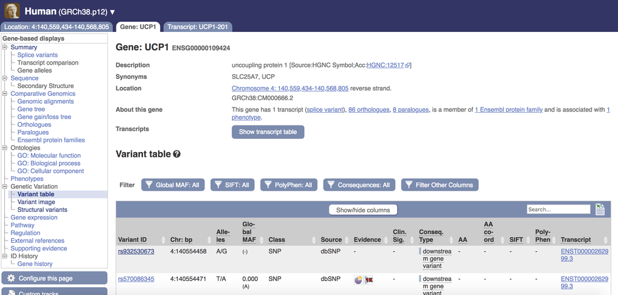

- In the search bar at the top right of the variant table, type in the SNP ID number for one of your SNPs that’s not in Hardy-Weinberg Equilibrium and search it. I will use the SNP rs6818140 to demonstrate this.

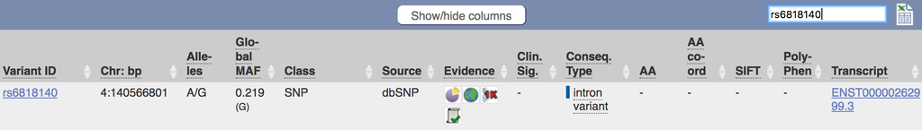

- When you have found your SNP in the table, you should first make note of the consequence type of the SNP. For example, rs6818140 is an intron variant. How do you think the consequence type will affect the kind of SNP?
- Next, click on the SNP ID to get to the SNP page. From there, click on the “Population Genetics” tab to get the population genetics table.
- Find the “Genotype Frequency” column in this table:

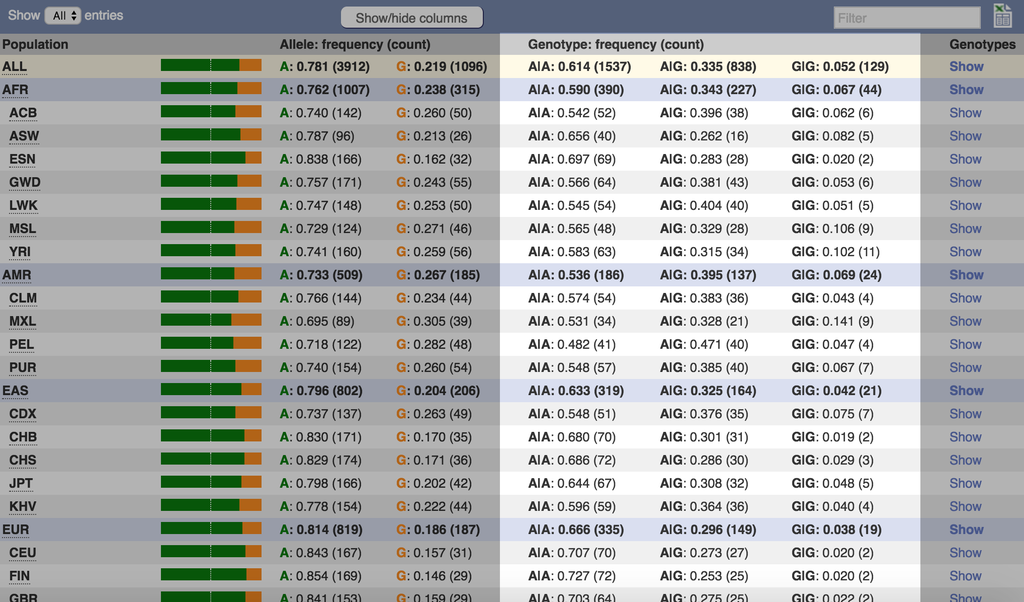

## Step 4: What Do Your Results Mean? Discuss with a partner:

Think about the results you produced today in the context of your population. Here are some guiding questions to help you:  
* If your population had SNPs that were not in Hardy-Weinberg Equilibrium, what kind of consequence did the SNP(s) have? How would that consequence type affect the phenotype?

- Does a SNP not being in Hardy-Weinberg Equilibrium mean that evolutionary forces are acting on it? How might evolutionary forces be acting on UCP1 if a SNP is not in Hardy-Weinberg Equilibrium?